# Agrupamiento Jerárquico. Aplicación de diferentes Linkages

Vamos a considerar un dataset con animales vertebrados cuyas caracteristicas binarias describen propiedades esenciales de un grupo de vertebrados (sangre caliente, extremidades,...). Los datos se encuentran en el fichero CSV 'vertebrate.csv'.

Los cargamos y visualizamos en forma de tabla los vectores de características binarios:

Andreu Cantó y Amparo Gálvez

```python
import pandas as pd

data = pd.read_csv('vertebrate.csv',header='infer')
data
```

|  | Name | Warm-blooded | Gives Birth | Aquatic Creature | Aerial Creature | Has Legs | Hibernates | Class |
| --- | --- | --- | --- | --- | --- | --- | --- | --- |
| 0 | human | 1 | 1 | 0 | 0 | 1 | 0 | mammals |
| 1 | python | 0 | 0 | 0 | 0 | 0 | 1 | reptiles |
| 2 | salmon | 0 | 0 | 1 | 0 | 0 | 0 | fishes |
| 3 | whale | 1 | 1 | 1 | 0 | 0 | 0 | mammals |
| 4 | frog | 0 | 0 | 1 | 0 | 1 | 1 | amphibians |
| 5 | komodo | 0 | 0 | 0 | 0 | 1 | 0 | reptiles |
| 6 | bat | 1 | 1 | 0 | 1 | 1 | 1 | mammals |
| 7 | pigeon | 1 | 0 | 0 | 1 | 1 | 0 | birds |
| 8 | cat | 1 | 1 | 0 | 0 | 1 | 0 | mammals |
| 9 | leopard shark | 0 | 1 | 1 | 0 | 0 | 0 | fishes |
| 10 | turtle | 0 | 0 | 1 | 0 | 1 | 0 | reptiles |
| 11 | penguin | 1 | 0 | 1 | 0 | 1 | 0 | birds |
| 12 | porcupine | 1 | 1 | 0 | 0 | 1 | 1 | mammals |
| 13 | eel | 0 | 0 | 1 | 0 | 0 | 0 | fishes |
| 14 | salamander | 0 | 0 | 1 | 0 | 1 | 1 | amphibians |

Importamos las librerias necesarias para el agrupamiento jerárquico y para plotear el resultado. Separamos la lista de las clases de vertebrados de los datos

```python
from scipy.cluster import hierarchy
import matplotlib.pyplot as plt
%matplotlib inline

names = data['Name']
Y = data['Class']
X = data.drop(['Name','Class'],axis=1)
print(Y)
print()
print(X)
```

```
0        mammals
1       reptiles
2         fishes
3        mammals
4     amphibians
5       reptiles
6        mammals
7          birds
8        mammals
9         fishes
10      reptiles
11         birds
12       mammals
13        fishes
14    amphibians
```

[output cut: 35 more lines]

### Agrupamiento con Linkage tipo 'Single Link'

Llamamos al método linkage con la distancia entre clusters de tipo Single Link. Generamos un dendrograma como resultado visual estandard de este tipo de agrupamiento

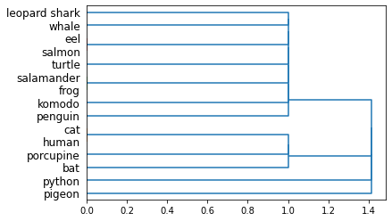

```python
Z = hierarchy.linkage(X.to_numpy(), 'single')
dn = hierarchy.dendrogram(Z,labels=names.tolist(),orientation='right') #puedes cambiar a la orientacion que te guste
```

**Pregunta1:** Explica aquí cada una de la dos líneas anteriores con sus parámetros y sus conversiones. Consulta para ello las páginas de referencia OnLine de la librería.

**Z = hierarchy.linkage(X.to_numpy(), 'single')**  
**X.to_numpy()** -> se utiliza para convertir los datos en X en una matriz NumPy.  
**'single'** -> método de enlace que se utiliza para calcular las distancias entre clústeres en el análisis de clustering jerárquico.  
**dn = hierarchy.dendrogram(Z, labels=names.tolist(), orientation='right')**  
**Z** -> matriz de enlace jerárquico que se calculó en la línea anterior.  
**labels** -> lista de etiquetas que se asocian a los puntos de datos en X, estas etiquetas se utilizan para etiquetar los nodos del dendrograma.  
**orientation** -> especifica la orientación del dendrograma, el dendrograma se dibujará verticalmente con los clústeres a la derecha de los nodos hoja.

**Pregunta2:** ¿Con que métrica para los elementos del dataset estamos midiendo la distancia? (no te pregunto por el linkage). Ejecuta la caja anterior con la distancia de Hamming'. ¿Observas alguna diferencia? ¿Por qué?

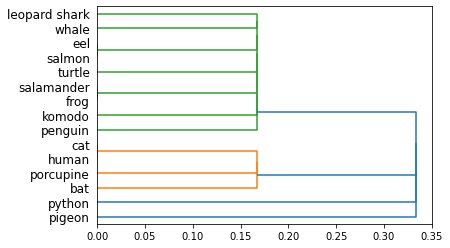

```python
distances_hamming = pdist(X.to_numpy(), metric='hamming')

Z = hierarchy.linkage(distances_hamming, 'single')

dn = hierarchy.dendrogram(Z, labels=names.tolist(), orientation='right')
```

### Agrupamiento con Linkage tipo 'Complete Linkage'

Realiza el mismo proceso que el anterior pero cambiando al Linkage que considera las distancias máximas entre los elementos de dos clusters. Consulta las páginas de referencia para sus nombres concretos.

**Usa e imprime el coeficiente cofenético.**

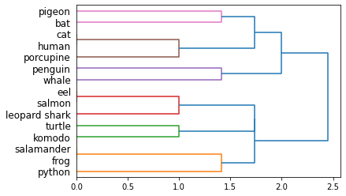

```python
Z = hierarchy.linkage(X.to_numpy(), 'complete')
dn = hierarchy.dendrogram(Z,labels=names.tolist(),orientation='right')
```

### Agrupamiento con Linkage tipo 'Average Linkage'

Realiza el mismo proceso que el anterior pero cambiando al Linkage que considera la distancia media entre los elementos de dos clusters. Consulta las páginas de referencia para sus nombres concretos.

**Usa e imprime el coeficiente cofenético.**

```
Coeficiente cofenético:  0.8406359207573233
```

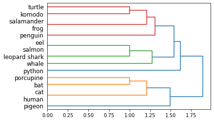

```python
Z = hierarchy.linkage(X.to_numpy(), 'average')
dn = hierarchy.dendrogram(Z,labels=names.tolist(),orientation='right')
dist = pdist(X)
coef_cofenetico,_ = hierarchy.cophenet(Z,dist)
print("Coeficiente cofenético: ",coef_cofenetico)
```

### Agrupamiento con Linkage tipo 'Centroid y Ward'

Realiza el código para los linkages de tipo 'Centroid' y 'Ward'. Consulta las páginas de referencia para sus nombres concretos.

**Usa e imprime el coeficiente cofenético.**

```
Coeficiente cofenético:  0.8089107616555786
```

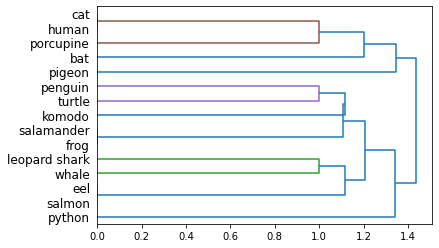

```python
#Centroide
Z = hierarchy.linkage(X.to_numpy(), 'centroid')
dn = hierarchy.dendrogram(Z,labels=names.tolist(),orientation='right')
dist = pdist(X)
coef_cofenetico,_ = hierarchy.cophenet(Z,dist)
print("Coeficiente cofenético: ",coef_cofenetico)
```

```
Coeficiente cofenético:  0.7314871163595956
```

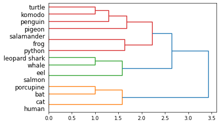

```python
#Ward
Z = hierarchy.linkage(X.to_numpy(), 'ward')
dn = hierarchy.dendrogram(Z,labels=names.tolist(),orientation='right')
dist = pdist(X)
coef_cofenetico,_ = hierarchy.cophenet(Z,dist)
print("Coeficiente cofenético: ",coef_cofenetico)
```

No hay en el agrupamiento jerárquico una técnica estadística que nos ayude a determinar cuál es el número ideal de clusters. Una regla empírica consiste en buscar en el dendrograma grupos que se forman a altas distancias. Otra regla que también funciona en algunos problemas es buscar los grupos donde la diferencia de distancias respecto a los anteriores agrupamientos (gap) sea más alta.

**Pregunta 3:** Observa los dendrogramas que has obtenido e indica en cuál se ve más claramente un corte siguiendo estos criterios y si tiene sentido en el dataset de vertebrados.

**Pregunta 4:** Compara los diferentes dendrogramas obtenidos con las Clases de los animales que contienen los clusters obtenidos, en los diferentes niveles de distancias de grupos. Comenta tus conclusiones acerca de la calidad de cada método. Comentario (discusión lo más informativa posible. Extiéndete lo necesario):

**Enlace Simple (Single Linkage):**se fundamenta en la menor distancia entre puntos de diferentes clústeres. Resulta efectivo para detectar estructuras lineales en los datos y tiende a evitar la fusión de grandes clústeres. No obstante, es susceptible al ruido, lo que puede conducir a clústeres largos o incoherentes.  
En este dendograma vemos que en una distancia 1.1 se generan 4 grupos, en el primer grupo hay especies de los 5 tipos; en el segundo grupo, se encuentran los mamiferos excepto la ballena; y en el tercer y cuarto grupo un pájaro y un reptil reprectivamente.

**Enlace Completo (Complete Linkage):** se basa en la máxima distancia entre puntos de diferentes clústeres. Funciona bien en conjuntos de datos con estructuras esféricas y favorece la detección de clústeres compactos. Sin embargo, puede fusionar clústeres inapropiados, lo que conduce a la formación de clústeres de tamaños desiguales.  
En distancia 1.6 se genran 6 gurpos y en diatncia 1.9 se generan 3 grupos, comparando vemos que se clasifica mejjor el corte que forma 3 grupos.  
En estos grupos vemos que los mamiferos y los pájaros se clasifican correctamente exceptuando uno de cada grupo que deberían estar intercambiados. En el tercer grupo se encuentran tanto peces como anfibios y reptiles.

**Enlace Promedio (Average Linkage):** Este enfoque calcula la distancia promedio entre pares de puntos de diferentes clústeres. Es más resistente que el enlace simple y completo, ideal para detectar estructuras irregulares. Pero puede verse afectado por valores atípicos y ruido, resultando en clústeres de tamaños y formas irregulares.  
La distancia 1.4 obtenemos 5 grupos que agrupa los mamiferos y los peces correctamente, en otro grupo añade reptiles y anfibios y en los dos restantes hay un grupo con un pájaro y otro con un reptil.

**Enlace de Ward:** Minimiza la varianza dentro de cada clúster al fusionar clústeres que minimizan el aumento total de la varianza. Es efectivo para datos con clústeres de diferentes formas y tamaños.  
Si cortamos en distancia 2 se genran 4 grupos. Los mamiferos, peces y reptiles se agrupan correctamente exceptuando dos animales, y el otro grupo añade tanto pájaros como reptiles.  
En general, el método 'average' parece proporcionar los resultados más coherentes y representativos de las cinco categorías de animales en el dataset. Sin embargo, en todos los métodos, se observan desafíos para lograr una agrupación perfecta.  
Si nos fijamos en los coeficientes cofenéticos vemos que el método average es el que mayor valor tiene, es decir, el más próximo a 1, por tanto, el que captura de manera más precisa las relaciones de similitud o distancia entre los datos originales.